# Homework 01

## Crear un cuaderno interactivo en Jupyter Notebook y Google Colab

### Introducción Pandas

[figure not shown]

```python
import pandas as pd
csv = 'C:/Users/Usuario/Data Science/Machine Learning and Deep Learning Course - UNAL/Homeworks/titanic.csv'
df = pd.read_csv(csv)
print(df.head())
```

```
   Survived  Pclass                                               Name  \
0         0       3                             Mr. Owen Harris Braund
1         1       1  Mrs. John Bradley (Florence Briggs Thayer) Cum...
2         1       3                              Miss. Laina Heikkinen
3         1       1        Mrs. Jacques Heath (Lily May Peel) Futrelle
4         0       3                            Mr. William Henry Allen

      Sex   Age  Siblings/Spouses Aboard  Parents/Children Aboard     Fare
0    male  22.0                        1                        0   7.2500
1  female  38.0                        1                        0  71.2833
2  female  26.0                        0                        0   7.9250
3  female  35.0                        1                        0  53.1000
4    male  35.0                        0                        0   8.0500
```

```python
# Seleccionar columnas específicas
print(df.columns)
```

```
Index(['Survived', 'Pclass', 'Name', 'Sex', 'Age', 'Siblings/Spouses Aboard',
       'Parents/Children Aboard', 'Fare'],
      dtype='object')
```

```python
df_subset = df[['Survived', 'Sex', 'Age']]
print(df_subset.head())
```

```
   Survived     Sex   Age
0         0    male  22.0
1         1  female  38.0
2         1  female  26.0
3         1  female  35.0
4         0    male  35.0
```

```python
# Filtrar datos
df_male = df[df['Sex'] == 'male']
print(df_male.head())
```

```
   Survived  Pclass                           Name   Sex   Age  \
0         0       3         Mr. Owen Harris Braund  male  22.0
4         0       3        Mr. William Henry Allen  male  35.0
5         0       3                Mr. James Moran  male  27.0
6         0       1         Mr. Timothy J McCarthy  male  54.0
7         0       3  Master. Gosta Leonard Palsson  male   2.0

   Siblings/Spouses Aboard  Parents/Children Aboard     Fare
0                        1                        0   7.2500
4                        0                        0   8.0500
5                        0                        0   8.4583
6                        0                        0  51.8625
7                        3                        1  21.0750
```

```python
# Crear una nueva columna
df['FamilySize'] = df['Siblings/Spouses Aboard'] + df['Pclass'] + 1
print(df.head())
```

```
   Survived  Pclass                                               Name  \
0         0       3                             Mr. Owen Harris Braund
1         1       1  Mrs. John Bradley (Florence Briggs Thayer) Cum...
2         1       3                              Miss. Laina Heikkinen
3         1       1        Mrs. Jacques Heath (Lily May Peel) Futrelle
4         0       3                            Mr. William Henry Allen

      Sex   Age  Siblings/Spouses Aboard  Parents/Children Aboard     Fare  \
0    male  22.0                        1                        0   7.2500
1  female  38.0                        1                        0  71.2833
2  female  26.0                        0                        0   7.9250
3  female  35.0                        1                        0  53.1000
4    male  35.0                        0                        0   8.0500

   FamilySize
0           5
1           3
2           4
3           3
4           4
```

[figure not shown]

```python
import matplotlib.pyplot as plt
# Contar el número de pasajeros masculinos y femeninos
gender_counts = df['Sex'].value_counts()
print(gender_counts)
```

```
male      573
female    314
Name: Sex, dtype: int64
```

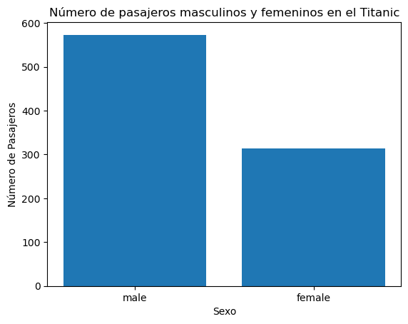

```python
plt.bar(gender_counts.index, gender_counts.values)
plt.xlabel('Sexo')
plt.ylabel('Número de Pasajeros')
plt.title('Número de pasajeros masculinos y femeninos en el Titanic')
plt.show()
```

**El gráfico de barras que se generó representa el número de pasajeros masculinos y femeninos en el conjunto de datos del Titanic. En el eje x, se encuentran las dos categorías: "male" y "female", que representan los pasajeros hombres y mujeres, respectivamente. En el eje y, se encuentra el número de pasajeros correspondiente a cada categoría. El gráfico de barras es una forma efectiva de visualizar la distribución de una variable categórica (en este caso, el género) en un conjunto de datos. En este gráfico en particular, podemos observar que hay más pasajeros hombres que mujeres en el conjunto de datos del Titanic. Esto coincide con lo que sabemos de la historia del Titanic, donde había una mayor proporción de hombres a bordo del barco que de mujeres. El gráfico también tiene un título descriptivo y etiquetas claras para los ejes x e y, lo que facilita la interpretación de la información presentada en él**

Se utiliza la biblioteca de NumPy para realizar algunas operaciones matemáticas en los datos (calcular la media, la desviación estándar o la varianza de los datos)

```python
import numpy as np

# Cálculo de la media de la edad de los pasajeros
mean_age = np.mean(df['Age'])
print("La media de edad de los pasajeros es: ", mean_age)

# Cálculo de la desviación estándar de la edad de los pasajeros
std_age = np.std(df['Age'])
print("La desviación estándar de la edad de los pasajeros es: ", std_age)

# Cálculo de la varianza de la edad de los pasajeros
var_age = np.var(df['Age'])
print("La varianza de la edad de los pasajeros es: ", var_age)
```

```
La media de edad de los pasajeros es:  29.471443066516347
La desviación estándar de la edad de los pasajeros es:  14.113945671023176
La varianza de la edad de los pasajeros es:  199.20346240459386
```

Otra opción:

```python
import pandas as pd
df.describe()
```

|  | Survived | Pclass | Age | Siblings/Spouses Aboard | Parents/Children Aboard | Fare | FamilySize |
| --- | --- | --- | --- | --- | --- | --- | --- |
| count | 887.000000 | 887.000000 | 887.000000 | 887.000000 | 887.000000 | 887.00000 | 887.000000 |
| mean | 0.385569 | 2.305524 | 29.471443 | 0.525366 | 0.383315 | 32.30542 | 3.830891 |
| std | 0.487004 | 0.836662 | 14.121908 | 1.104669 | 0.807466 | 49.78204 | 1.441341 |
| min | 0.000000 | 1.000000 | 0.420000 | 0.000000 | 0.000000 | 0.00000 | 2.000000 |
| 25% | 0.000000 | 2.000000 | 20.250000 | 0.000000 | 0.000000 | 7.92500 | 3.000000 |
| 50% | 0.000000 | 3.000000 | 28.000000 | 0.000000 | 0.000000 | 14.45420 | 4.000000 |
| 75% | 1.000000 | 3.000000 | 38.000000 | 1.000000 | 0.000000 | 31.13750 | 4.000000 |
| max | 1.000000 | 3.000000 | 80.000000 | 8.000000 | 6.000000 | 512.32920 | 12.000000 |

**Mean:** corresponde a la media aritmetica, es decir la suma de todos los valores dividido el número de datos, en este caso se considera solo la columna o campo de Age (Edad).

**Std:** corresponde a la desviación estándar, representa la dispersión de los datos.

**Var:** corresponde a la varianza que a su vez representa el cuadrado de la desviacion estandar y por lo tanto también es una medida de dispersión.

[13 Most Important Pandas Functions for Data Science][https://www.analyticsvidhya.com/blog/2021/05/pandas-functions-13-most-important/]